# Coding songs as sequences of 5 ms segments

Understanding cultural evolution of songs in hummingbird leks through the fossilized birth-death process

Author

[Marcelo Araya-Salas](https://marce10.github.io/)

Published

November 6, 2026

Source code and data found at https://github.com/maRce10/lbh_cultural_evolution_revBayes

# Purpose

Code each song as a sequence of 5 ms segments with 5 possible states, in four steps:

1. **Broad sections**: the manual segmentation of the prevalence data set defines the boundaries of each section and whether it is a pure tone or a trill
2. **Classify trills**: each whole trill section is assigned to fast or slow from its trill period
3. **Split into 5 ms segments**: trill segments inherit the state of their section
4. **Classify tones**: each 5 ms tone segment is assigned to descending, flat or ascending from the local frequency slope

# Load packages

```r
sketchy::load_packages(packages = c("knitr", "Rraven", "ggplot2", "viridis", "tuneR", "seewave", "mclust", "diptest"))

theme_set(theme_classic(base_size = 13))
knitr::opts_chunk$set(message = FALSE, warning = FALSE, dpi = 120, fig.retina = 1)

states <- c("D", "P", "U", "F", "S")
state_names <- c("D: descending tone", "P: flat tone", "U: ascending tone", "F: fast trill", "S: slow trill")
cat_cols <- setNames(viridis(5, option = "H", begin = 0.05, end = 0.95), states)
txt_col <- setNames(c("white", "black", "black", "black", "white"), states)

# parameters of the coding
segment_ms <- 5              # duration of the segments
trill_cut_ms <- 13           # fast < 13 ms <= slow
tone_cut <- 5                # D < -5 kHz/s <= P < 5 kHz/s <= U
tone_window_ms <- 5          # slope measured on the segment +- 5 ms (15 ms in total)
```

# 1 Step 1: broad sections

Manual segments and tailored contours from the prevalence data set, with two corrections: segments annotated with the wrong song are reassigned to the song whose contour contains them, and W segments (a rapid frequency sweep) are treated as tones. Only the boundaries and the broad class of the manual labels are used: **tone** (D, U, P, W) or **trill** (F, M, S).

```r
contours <- read.csv("./data/raw/segment_classification/seltailor_output.csv")
ff_cols <- grep("^ff", names(contours))

segs <- imp_raven(path = "./data/raw/segment_classification", files = "FrameworkContourDegradationv1.7.txt",
                  all.data = TRUE, warbler.format = TRUE)
segs <- segs[!is.na(segs$Category) & segs$Category != "" & segs$ID %in% contours$song.type, ]

# reassign segments annotated with the wrong song
tol <- 0.005
m <- match(segs$ID, contours$song.type)
outside <- segs$end < contours$start[m] - tol | segs$start > contours$end[m] + tol
segs$ID[outside] <- vapply(which(outside), function(i) {
  k <- which(contours$start <= segs$start[i] + tol & contours$end >= segs$end[i] - tol)
  if (length(k) == 1) contours$song.type[k] else NA_character_
}, character(1))
segs <- segs[!is.na(segs$ID), ]
segs <- segs[order(segs$ID, segs$start), ]

segs$manual <- ifelse(segs$Category == "W", "U", segs$Category)
segs$class <- ifelse(segs$manual %in% c("F", "M", "S"), "trill", "tone")
segs$lek.song.type <- sub("-[0-9]{4}$", "", sub("^[0-9]+-", "", segs$ID))
segs$lek <- sub("-.*", "", segs$lek.song.type)
segs$duration_ms <- (segs$end - segs$start) * 1000

data.frame(recordings = length(unique(segs$ID)), song_types = length(unique(segs$lek.song.type)), sections = nrow(segs))
```

| recordings | song_types | sections |
| --- | --- | --- |
| 322 | 187 | 1618 |

```r
table(segs$class)
```

```
 tone trill
 1253   365
```

```r
# contour of each recording
CT <- lapply(split(contours, contours$song.type), function(ct)
  list(t = seq(ct$start, ct$end, length.out = length(ff_cols)), f = unlist(ct[, ff_cols]), start = ct$start, end = ct$end))

# slope (kHz/s) and trill period (ms) of the contour in a time window
measure <- function(id, a, b) {
  k <- CT[[id]]
  n <- max(8, sum(k$t >= a & k$t <= b))
  ti <- seq(a, b, length.out = n)
  fi <- approx(k$t, k$f, xout = ti, rule = 2)$y
  d1 <- diff(fi); sg <- sign(d1[abs(d1) > 0.05])
  n_ext <- if (length(sg) > 1) sum(diff(sg) != 0) else 0
  osc <- n_ext / 2 / (b - a)
  c(slope = unname(coef(lm(fi ~ ti))[2]), period_ms = if (osc > 0) 1000 / osc else Inf)
}
```

# 2 Step 2: classify trills

The **trill period** (ms per oscillation cycle) of each whole trill section is 1000 / oscillation rate, where the oscillation rate is half the number of direction changes of the contour per second (changes < 50 Hz ignored). A section is needed for this measurement: a 5 ms segment is much shorter than one trill cycle.

```r
tr_idx <- which(segs$class == "trill")
segs$period_ms <- NA
segs$period_ms[tr_idx] <- mapply(function(id, a, b) measure(id, a, b)[["period_ms"]],
                                 segs$ID[tr_idx], segs$start[tr_idx], segs$end[tr_idx])
segs$trill_state <- ifelse(segs$class == "trill", ifelse(segs$period_ms < trill_cut_ms, "F", "S"), NA)
```

## 2.1 Natural groups in trill period

```r
x <- segs$period_ms[tr_idx]; x <- x[is.finite(x)]
bic <- mclustBIC(x, G = 1:5, modelNames = "V", verbose = FALSE)
mod <- Mclust(x, G = which.max(bic[, "V"]), modelNames = "V", verbose = FALSE)

data.frame(groups = 1:5, BIC = round(bic[, "V"]))
```

| groups | BIC |
| --- | --- |
| 1 | -2363 |
| 2 | -2186 |
| 3 | -2200 |
| 4 | -2215 |
| 5 | -2233 |

```r
data.frame(mean_ms = round(mod$parameters$mean, 1), sd_ms = round(sqrt(mod$parameters$variance$sigmasq), 1), proportion = round(mod$parameters$pro, 2))
```

| mean_ms | sd_ms | proportion |
| --- | --- | --- |
| 10.2 | 1.6 | 0.52 |
| 19.3 | 5.7 | 0.48 |

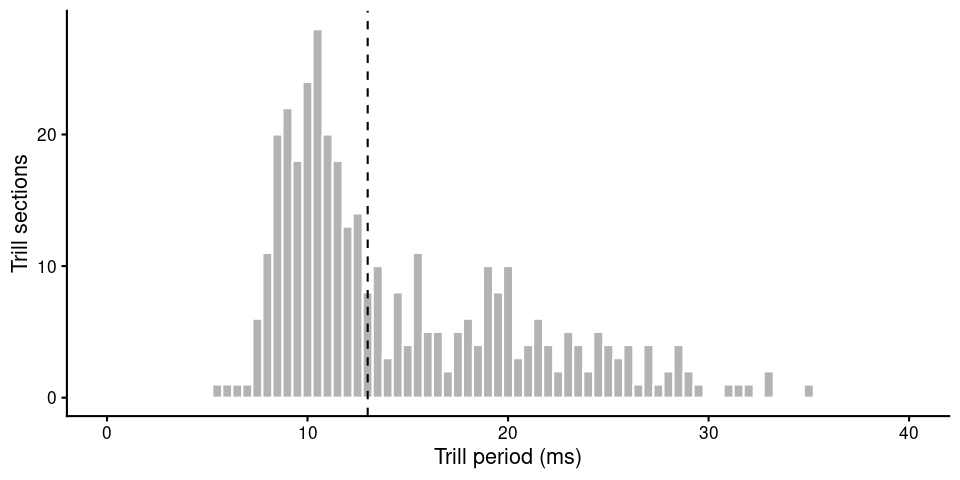

```r
ggplot(data.frame(x), aes(x)) +
  geom_histogram(binwidth = 0.5, fill = "gray70", color = "white") +
  geom_vline(xintercept = trill_cut_ms, linetype = 2) +
  coord_cartesian(xlim = c(0, 40)) + labs(x = "Trill period (ms)", y = "Trill sections")
```

A mixture of two groups is preferred (BIC): fast trills (~10 ms) and slow trills (~20 ms). The dashed line marks the threshold used (13 ms), close to the point at which the two groups are equally likely.

# 3 Step 3: split into 5 ms segments

Each song (from the start to the end of its tailored contour) is split into consecutive 5 ms segments. A last remainder of at least half a segment forms its own (shorter) segment, and a shorter remainder is added to the previous segment. Each segment belongs to the section that covers most of it, and trill segments inherit the state of their section.

```r
split_song <- function(id) {
  ii <- which(segs$ID == id); k <- CT[[id]]; d <- segment_ms / 1000
  b <- seq(k$start, k$end, by = d)
  if (k$end - b[length(b)] >= d / 2 || length(b) == 1) b <- c(b, k$end) else b[length(b)] <- k$end
  n <- length(b) - 1
  data.frame(ID = id, segment = 1:n, start = b[-(n + 1)], end = b[-1],
             section = sapply(1:n, function(j) ii[which.max(pmax(0, pmin(segs$end[ii], b[j + 1]) - pmax(segs$start[ii], b[j])))]))
}
P <- do.call(rbind, lapply(unique(segs$ID), split_song))
P$class <- segs$class[P$section]
P$manual <- segs$manual[P$section]
P$former_W <- segs$Category[P$section] == "W"
P$lek.song.type <- segs$lek.song.type[P$section]
P$taxon <- sub("^[0-9]+-", "", P$ID)
P$year <- as.numeric(sub(".*-", "", P$ID))

data.frame(segments = nrow(P), tone = sum(P$class == "tone"), trill = sum(P$class == "trill"))
```

| segments | tone | trill |
| --- | --- | --- |
| 9008 | 4200 | 4808 |

# 4 Step 4: classify tones

The **frequency slope** of each tone segment is measured with a linear fit to the contour in a 15 ms window centred on the segment (kept within its section). The window reduces the effect of small irregularities of the contour while still following changes in direction within a section.

Thresholds: **D** < -5 kHz/s ≤ **P** < 5 kHz/s ≤ **U**.

```r
to_idx <- which(P$class == "tone")
w <- tone_window_ms / 1000
P$slope <- NA
P$slope[to_idx] <- sapply(to_idx, function(i) {
  s <- P$section[i]
  a <- max(P$start[i] - w, segs$start[s]); b <- min(P$end[i] + w, segs$end[s])
  if (b - a < 0.002) { a <- segs$start[s]; b <- segs$end[s] }
  measure(P$ID[i], a, b)[["slope"]]
})

P$state <- ifelse(P$class == "trill", segs$trill_state[P$section],
                  ifelse(P$slope < -tone_cut, "D", ifelse(P$slope < tone_cut, "P", "U")))

round(prop.table(table(factor(P$state, states))), 3)
```

```
    D     P     U     F     S
0.154 0.047 0.265 0.285 0.248
```

Slope distribution of the tone segments, on a signed log scale (dashed lines: thresholds):

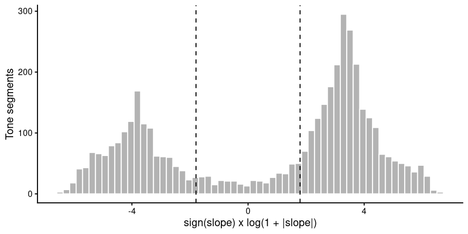

```r
sl <- P$slope[to_idx]
ggplot(data.frame(x = sign(sl) * log1p(abs(sl))), aes(x)) +
  geom_histogram(bins = 60, fill = "gray70", color = "white") +
  geom_vline(xintercept = c(-1, 1) * log1p(tone_cut), linetype = 2) +
  labs(x = "sign(slope) x log(1 + |slope|)", y = "Tone segments")
```

## 4.1 Former W segments

W segments are rapid frequency sweeps. Classifying tones per segment splits them into their rising and falling parts:

```r
round(prop.table(table(factor(P$state[P$former_W], c("D", "P", "U")))), 3)
```

```
   D    P    U
0.43 0.02 0.55
```

# 5 Sequences

Three tables are saved in `data/processed`:

- `song_5ms_segments_by_recording.csv`: all segments with their state
- `song_5ms_sequences_by_taxon.csv`: the sequence of each song type and year (one recording per song type and year)
- `song_5ms_sequences_by_song_type.csv`: one sequence per song type, from its **most representative recording** (highest mean similarity to the other recordings of the song type). A position-by-position consensus is not used because sequences differ in length

```r
Q <- lapply(split(P, factor(P$ID, levels = unique(P$ID))), function(z) z$state[order(z$segment)])
seq_str <- sapply(Q, paste, collapse = "")

similarity <- function(a, b) 1 - adist(seq_str[[a]], seq_str[[b]])[1, 1] / max(nchar(seq_str[[a]]), nchar(seq_str[[b]]))

rec <- unique(P[, c("ID", "lek.song.type", "taxon", "year")])
rec$lek <- sub("-.*", "", rec$lek.song.type)
rec$length <- nchar(seq_str[rec$ID])
rec$sequence <- tolower(seq_str[rec$ID])

by_type <- do.call(rbind, lapply(split(rec, rec$lek.song.type), function(z) {
  if (nrow(z) == 1) { best <- 1; ms <- NA } else {
    S <- outer(z$ID, z$ID, Vectorize(similarity)); diag(S) <- NA
    ms <- rowMeans(S, na.rm = TRUE); best <- which.max(ms); ms <- ms[best]
  }
  data.frame(lek = z$lek[1], song.type = z$lek.song.type[1], n_recordings = nrow(z), representative_recording = z$ID[best],
             mean_similarity_to_others = round(ms, 3), length = z$length[best], sequence = z$sequence[best])
}))

write.csv(P[, c("ID", "lek.song.type", "taxon", "year", "segment", "start", "end", "class", "manual", "slope", "state")],
          "./data/processed/song_5ms_segments_by_recording.csv", row.names = FALSE)
write.csv(rec[, c("lek", "lek.song.type", "year", "taxon", "ID", "length", "sequence")],
          "./data/processed/song_5ms_sequences_by_taxon.csv", row.names = FALSE)
write.csv(by_type, "./data/processed/song_5ms_sequences_by_song_type.csv", row.names = FALSE)

data.frame(taxa = nrow(rec), song_types = nrow(by_type), median_length = median(rec$length), min_length = min(rec$length), max_length = max(rec$length))
```

| taxa | song_types | median_length | min_length | max_length |
| --- | --- | --- | --- | --- |
| 322 | 187 | 28 | 18 | 43 |

```r
head(by_type[, c("song.type", "n_recordings", "length", "sequence")])
```

|  | song.type | n_recordings | length | sequence |
| --- | --- | --- | --- | --- |
| BR1-A1 | BR1-A1 | 4 | 30 | ssssssssfffffffffddddddddddddu |
| BR1-A2 | BR1-A2 | 1 | 27 | uuduussssssssssuudddddddddd |
| BR1-C1 | BR1-C1 | 4 | 29 | dpppuuusssssssssssfffffffffdd |
| BR1-C2 | BR1-C2 | 1 | 31 | uuuuuusssssssssssssffffffffffdd |
| BR1-D1 | BR1-D1 | 3 | 28 | ffffffffffffffffffffffffffdd |
| BR1-D2 | BR1-D2 | 1 | 29 | uuuuuuuffffffffffffddfffffddd |

## 5.1 FASTA files for alignment

FASTA files are saved in `data/processed/song_sequences_5ms`, with the same taxa and file names used for the 20-segment sequences (`data/processed/song_sequences`), so they can be used in the same alignment steps. For each lek, taxa are split into `early_old`, `rest_old`, `early_new`, `rest_new` and `no.fossils`, following `aligning_song_types.Rmd`. The original alignments are not modified.

Each set comes in two formats:

- `song_seqs_<set>_<lek>.fa`: states as lower-case letters (d, p, u, f, s), for MAFFT
- `song_seqs_<set>_<lek>_prank.fa`: nucleotide coding for PRANK, as in the previous analyses: trills as pyrimidines (f = C, s = T) and tones as purines (u = A, d = G, with flat tones ambiguous between them, p = R)

Sequences of taxa are provided in two versions, in separate folders:

- `song_type_sequence`: all years of a song type share the sequence of its most representative recording (as in the previous analyses, in which a song type had a single sequence)
- `year_specific_sequence`: each song type and year has the sequence of its own recording. Taxa with no recording in that year (years between the first and last record of the song type) use the representative sequence of the song type

`taxon_sequence_source.csv` gives the recording used for each taxon, and `all_recordings.fa` has the sequences of all recordings.

```r
sel_leks <- c("BR1", "CCE", "HC1", "SUR", "TR1")
out_dir <- "./data/processed/song_sequences_5ms"
for (d in c("song_type_sequence", "year_specific_sequence")) dir.create(file.path(out_dir, d), recursive = TRUE, showWarnings = FALSE)

to_prank <- function(x) chartr("fsudp", "CTAGR", x)
write_fasta <- function(names, seqs, file) writeLines(as.vector(rbind(paste0(">", names), seqs)), file)

yrs <- read.csv("./data/raw/year_range_by_song_type.csv", stringsAsFactors = FALSE)
yrs <- yrs[yrs$lek %in% sel_leks, ]
yrs$taxon <- paste(yrs$song.type, yrs$year, sep = "-")
yrs <- yrs[order(yrs$song.type, yrs$year), ]

# sequence of each taxon
yrs$representative_recording <- by_type$representative_recording[match(yrs$song.type, by_type$song.type)]
yrs$own_recording <- rec$ID[match(yrs$taxon, rec$taxon)]
yrs$has_recording <- !is.na(yrs$own_recording)
yrs$seq_song_type <- by_type$sequence[match(yrs$song.type, by_type$song.type)]
yrs$seq_year <- ifelse(yrs$has_recording, rec$sequence[match(yrs$taxon, rec$taxon)], yrs$seq_song_type)
stopifnot(!anyNA(yrs$seq_song_type))

write.csv(data.frame(lek = yrs$lek, taxon = yrs$taxon, song.type = yrs$song.type, year = yrs$year,
                     has_recording_that_year = yrs$has_recording,
                     recording_song_type_sequence = yrs$representative_recording,
                     recording_year_specific_sequence = ifelse(yrs$has_recording, yrs$own_recording, yrs$representative_recording)),
          file.path(out_dir, "taxon_sequence_source.csv"), row.names = FALSE)
write_fasta(rec$ID, rec$sequence, file.path(out_dir, "all_recordings.fa"))

# taxon sets (as in aligning_song_types.Rmd)
all_old <- yrs
early_old <- all_old[!duplicated(all_old$song.type), ]
all_new <- all_old[all_old$year > 2000, ]
early_new <- early_old[early_old$year > 2000, ]
rest_old <- all_old[!all_old$taxon %in% early_old$taxon, ]
rest_new <- all_new[!all_new$taxon %in% early_new$taxon, ]
no_fossils <- do.call(rbind, lapply(split(all_old, all_old$lek), function(z) z[z$year == max(z$year), ]))

sets <- list(early_old = early_old, rest_old = rest_old, early_new = early_new, rest_new = rest_new, no.fossils = no_fossils)
n_files <- 0
for (i in sel_leks) for (set in names(sets)) {
  z <- sets[[set]][sets[[set]]$lek == i, ]
  if (grepl("old", set) && !any(all_old$year[all_old$lek == i] < 2000)) next
  if (set == "no.fossils" && nrow(z) <= 3) next
  if (!nrow(z)) next
  for (v in c("song_type_sequence", "year_specific_sequence")) {
    sq <- if (v == "song_type_sequence") z$seq_song_type else z$seq_year
    write_fasta(z$taxon, sq, file.path(out_dir, v, paste0("song_seqs_", set, "_", i, ".fa")))
    write_fasta(z$taxon, to_prank(sq), file.path(out_dir, v, paste0("song_seqs_", set, "_", i, "_prank.fa")))
    n_files <- n_files + 2
  }
}

# number of taxa per set, compared with the taxa sets of the previous analyses
n_tax <- function(set, lek) { f <- file.path(out_dir, "song_type_sequence", paste0("song_seqs_", set, "_", lek, ".fa")); if (file.exists(f)) sum(grepl("^>", readLines(f))) else 0 }
n_prev <- function(set, lek) { f <- file.path("./data/processed/song_sequences", paste0("song_seqs_", set, "_", lek, ".fa")); if (file.exists(f)) sum(grepl("^>", readLines(f))) else 0 }
check <- expand.grid(lek = sel_leks, set = names(sets), stringsAsFactors = FALSE)
check$taxa <- mapply(n_tax, check$set, check$lek); check$taxa_previous <- mapply(n_prev, check$set, check$lek)
xtabs(taxa ~ lek + set, check)
```

```
     set
lek   early_new early_old no.fossils rest_new rest_old
  BR1        12         0          9       11        0
  CCE         9        21          0       16       30
  HC1         6        20          0        6       11
  SUR        24        38          5       41       62
  TR1        13         0          8       20        0
```

```r
all(check$taxa == check$taxa_previous)
```

```
[1] TRUE
```

```r
data.frame(fasta_files = n_files, taxa = nrow(yrs), taxa_with_recording_that_year = sum(yrs$has_recording),
           taxa_using_representative_sequence = sum(!yrs$has_recording))
```

| fasta_files | taxa | taxa_with_recording_that_year | taxa_using_representative_sequence |
| --- | --- | --- | --- |
| 76 | 238 | 197 | 41 |

# 6 Evaluation

## 6.1 Similarity between copies of the same song type

Similarity between two sequences is 1 - edit distance / length of the longer sequence. The baseline is the similarity between recordings of different song types from the same lek.

```r
same <- do.call(rbind, lapply(split(rec$ID, rec$lek.song.type), function(z) if (length(z) > 1) t(combn(z, 2)) else NULL))
same_sim <- apply(same, 1, function(p) similarity(p[1], p[2]))

set.seed(1)
diff_pairs <- do.call(rbind, lapply(split(rec, rec$lek), function(z) {
  if (length(unique(z$lek.song.type)) < 2) return(NULL)
  p <- t(combn(seq_len(nrow(z)), 2)); p <- p[z$lek.song.type[p[, 1]] != z$lek.song.type[p[, 2]], , drop = FALSE]
  p <- p[sample(nrow(p), min(300, nrow(p))), , drop = FALSE]
  cbind(z$ID[p[, 1]], z$ID[p[, 2]])
}))
diff_sim <- apply(diff_pairs, 1, function(p) similarity(p[1], p[2]))

fs <- list.files("./data/processed/fossils", pattern = "taxa_.*\\.tsv$", full.names = TRUE)
rb_taxa <- unique(unlist(lapply(fs, function(f) read.delim(f)[[1]])))
rb_types <- unique(sub("-[0-9]{4}$", "", rb_taxa))
same_type <- rec$lek.song.type[match(same[, 1], rec$ID)]
in_rb <- same_type %in% rb_types

data.frame(comparison = c("same song type", "same song type (RevBayes song types)", "different song types, same lek"),
           pairs = c(length(same_sim), sum(in_rb), length(diff_sim)),
           mean = round(c(mean(same_sim), mean(same_sim[in_rb]), mean(diff_sim)), 3),
           q25 = round(c(quantile(same_sim, .25), quantile(same_sim[in_rb], .25), quantile(diff_sim, .25)), 3),
           median = round(c(median(same_sim), median(same_sim[in_rb]), median(diff_sim)), 3),
           q75 = round(c(quantile(same_sim, .75), quantile(same_sim[in_rb], .75), quantile(diff_sim, .75)), 3))
```

| comparison | pairs | mean | q25 | median | q75 |
| --- | --- | --- | --- | --- | --- |
| same song type | 247 | 0.758 | 0.678 | 0.800 | 0.885 |
| same song type (RevBayes song types) | 182 | 0.771 | 0.690 | 0.815 | 0.889 |
| different song types, same lek | 2256 | 0.389 | 0.179 | 0.367 | 0.581 |

```r
data.frame(chance_corrected_similarity = round((mean(same_sim) - mean(diff_sim)) / (1 - mean(diff_sim)), 3),
           same_type_pairs_above_median_different_type = round(mean(same_sim > median(diff_sim)), 3))
```

| chance_corrected_similarity | same_type_pairs_above_median_different_type |
| --- | --- |
| 0.604 | 0.955 |

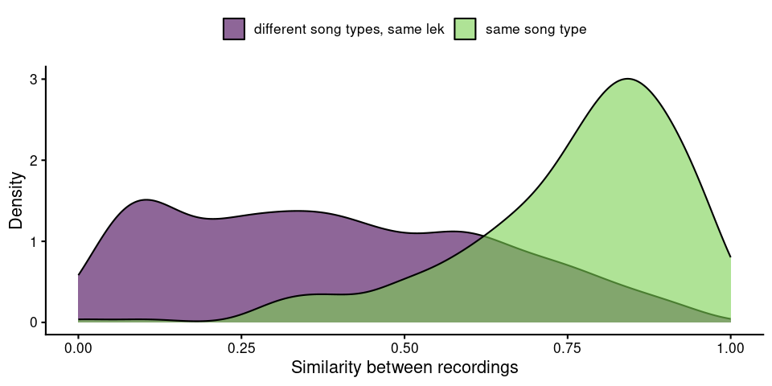

```r
ggplot(data.frame(similarity = c(same_sim, diff_sim),
                  comparison = rep(c("same song type", "different song types, same lek"), c(length(same_sim), length(diff_sim)))),
       aes(similarity, fill = comparison)) +
  geom_density(alpha = 0.6) + scale_fill_viridis_d(end = 0.8, name = NULL) +
  labs(x = "Similarity between recordings", y = "Density") + theme(legend.position = "top")
```

Similarity by lek and by time between recordings:

```r
rev_lek <- sub("-.*", "", same_type); k <- rev_lek %in% c("BR1", "CCE", "HC1", "SUR", "TR1")
data.frame(lek = names(table(rev_lek[k])), pairs = as.vector(table(rev_lek[k])), similarity = round(as.vector(tapply(same_sim[k], rev_lek[k], mean)), 3))
```

| lek | pairs | similarity |
| --- | --- | --- |
| BR1 | 15 | 0.776 |
| CCE | 28 | 0.607 |
| HC1 | 6 | 0.676 |
| SUR | 103 | 0.813 |
| TR1 | 30 | 0.798 |

```r
gap <- abs(rec$year[match(same[, 1], rec$ID)] - rec$year[match(same[, 2], rec$ID)])
bins <- cut(gap, c(0, 1, 2, 5, 60), labels = c("1", "2", "3-5", ">5"))
data.frame(years_apart = levels(bins), pairs = as.vector(table(bins)), similarity = round(as.vector(tapply(same_sim, bins, mean)), 3))
```

| years_apart | pairs | similarity |
| --- | --- | --- |
| 1 | 108 | 0.782 |
| 2 | 74 | 0.753 |
| 3-5 | 60 | 0.739 |
| >5 | 5 | 0.541 |

## 6.2 Agreement with the manual labels

Manual M trills have no equivalent in this coding (their segments are assigned to F or S by their period) and are excluded here; former W segments are compared as U.

```r
ref <- ifelse(P$manual == "M", NA, P$manual)
data.frame(segments = c("all (excluding manual M)", "trills (F, S)", "tones (D, P, U)", "tones, excluding former W"),
           agreement = round(c(mean(P$state == ref, na.rm = TRUE),
                               mean((P$state == ref)[P$class == "trill"], na.rm = TRUE),
                               mean((P$state == ref)[P$class == "tone"], na.rm = TRUE),
                               mean((P$state == ref)[P$class == "tone" & !P$former_W], na.rm = TRUE)), 3))
```

| segments | agreement |
| --- | --- |
| all (excluding manual M) | 0.892 |
| trills (F, S) | 0.955 |
| tones (D, P, U) | 0.854 |
| tones, excluding former W | 0.905 |

```r
table(manual = factor(P$manual, c("D", "P", "U", "F", "M", "S")), coded = factor(P$state, states))
```

```
      coded
manual    D    P    U    F    S
     D 1049   40   29    0    0
     P   51  277   98    0    0
     U  288  106 2262    0    0
     F    0    0    0  651   50
     M    0    0    0 1855  438
     S    0    0    0   64 1750
```

## 6.3 Redundancy

```r
run_len <- sapply(Q, function(z) length(z) / length(rle(z)$lengths))
data.frame(positions_per_run = round(mean(run_len), 2), runs_per_song = round(mean(sapply(Q, function(z) length(rle(z)$lengths))), 1))
```

| positions_per_run | runs_per_song |
| --- | --- |
| 6.54 | 5.1 |

## 6.4 Coverage of the RevBayes taxa

```r
data.frame(revbayes_song_types = length(rb_types), with_sequence = sum(rb_types %in% by_type$song.type),
           revbayes_taxa = length(rb_taxa), taxa_with_recording_that_year = sum(rb_taxa %in% rec$taxon))
```

| revbayes_song_types | with_sequence | revbayes_taxa | taxa_with_recording_that_year |
| --- | --- | --- | --- |
| 104 | 104 | 238 | 197 |

# 7 Agreement of the broad categories (tone vs. trill)

## 7.1 Between copies of the same song type

Two comparisons between all pairs of recordings of the same song type, using only the broad category of each segment: similarity of the 5 ms sequences (edit distance, as sequences differ in length) and position-by-position agreement after splitting each song into 20 equal-length parts (which can be compared directly with the previous 20-segment coding below).

```r
broad <- function(z) ifelse(toupper(z) %in% c("F", "S", "M"), "T", "N")
kappa <- function(a, b) {
  lv <- union(a, b); cm <- table(factor(a, lv), factor(b, lv))
  acc <- sum(diag(cm)) / sum(cm); pe <- sum(rowSums(cm) * colSums(cm)) / sum(cm)^2
  (acc - pe) / (1 - pe)
}

# 5 ms sequences
broad_str <- sapply(Q, function(z) paste(broad(z), collapse = ""))
broad_sim <- function(p) 1 - adist(broad_str[[p[1]]], broad_str[[p[2]]])[1, 1] / max(nchar(broad_str[[p[1]]]), nchar(broad_str[[p[2]]]))
same_broad <- apply(same, 1, broad_sim); diff_broad <- apply(diff_pairs, 1, broad_sim)

# 20 equal-length parts: broad category of the section covering most of each part
parts20 <- do.call(rbind, lapply(unique(segs$ID), function(id) {
  ii <- which(segs$ID == id); k <- CT[[id]]; b <- seq(k$start, k$end, length.out = 21)
  data.frame(ID = id, lek.song.type = segs$lek.song.type[ii[1]], segment = 1:20,
             broad = broad(segs$manual[sapply(1:20, function(j) ii[which.max(pmax(0, pmin(segs$end[ii], b[j + 1]) - pmax(segs$start[ii], b[j])))])]))
}))
B20 <- split(parts20$broad, parts20$ID)
a20 <- unlist(lapply(seq_len(nrow(same)), function(i) B20[[same[i, 1]]]))
b20 <- unlist(lapply(seq_len(nrow(same)), function(i) B20[[same[i, 2]]]))
d_a20 <- unlist(lapply(seq_len(nrow(diff_pairs)), function(i) B20[[diff_pairs[i, 1]]]))
d_b20 <- unlist(lapply(seq_len(nrow(diff_pairs)), function(i) B20[[diff_pairs[i, 2]]]))
pair_agree20 <- sapply(seq_len(nrow(same)), function(i) mean(B20[[same[i, 1]]] == B20[[same[i, 2]]]))

data.frame(measure = c("5 ms sequences, similarity", "20 equal-length parts, position by position"),
           pairs = nrow(same),
           same_song_type = round(c(mean(same_broad), mean(a20 == b20)), 3),
           q25 = round(c(quantile(same_broad, .25), quantile(pair_agree20, .25)), 3),
           median = round(c(median(same_broad), median(pair_agree20)), 3),
           q75 = round(c(quantile(same_broad, .75), quantile(pair_agree20, .75)), 3),
           different_song_types_same_lek = round(c(mean(diff_broad), mean(d_a20 == d_b20)), 3),
           kappa = c(NA, round(kappa(a20, b20), 3)))
```

| measure | pairs | same_song_type | q25 | median | q75 | different_song_types_same_lek | kappa |
| --- | --- | --- | --- | --- | --- | --- | --- |
| 5 ms sequences, similarity | 247 | 0.888 | 0.844 | 0.903 | 0.95 | 0.649 | NA |
| 20 equal-length parts, position by position | 247 | 0.927 | 0.900 | 0.950 | 1.00 | 0.674 | 0.853 |

## 7.2 With the previous manual 20-segment coding

The previous coding (`complete_segment_analysis_nov-2019.RDS`) assigned one of six states to each of the 20 equal-length segments of each recording. It is converted to two categories: trills (f, m, s) and tones (d, p, u). Each recording of this data set is compared position by position with all recordings of the same song type in the previous coding, and with the consensus of the song type (most common category at each position, built in temporal order). These are mostly different recordings of the song type, so they include variation between copies.

For reference, the table also includes the agreement between copies within the previous coding and between the two observers of the previous coding (`segment_classification_2_observers.csv`).

```r
prev <- as.data.frame(readRDS("./data/processed/complete_segment_analysis_nov-2019.RDS"))
prev <- prev[order(prev$sound.files, prev$start), ]
prev$segment <- ave(prev$start, prev$sound.files, FUN = seq_along)
prev$broad <- ifelse(grepl("t$", prev$segment_type), "T", "N")
P20 <- split(prev$broad, prev$sound.files)
prev_type <- tapply(prev$lek.song.type, prev$sound.files, `[`, 1)
prev_year <- tapply(prev$year, prev$sound.files, `[`, 1)

cur_type <- tapply(parts20$lek.song.type, parts20$ID, `[`, 1)
cur_year <- as.numeric(sub(".*-", "", names(cur_type)))
shared_types <- intersect(cur_type, prev_type)

# all recordings of this data set vs. all recordings of the previous coding of the same song type
cross <- do.call(rbind, lapply(shared_types, function(ty) {
  expand.grid(cur = names(cur_type)[cur_type == ty], pre = names(prev_type)[prev_type == ty], stringsAsFactors = FALSE)
}))
cross$same_year <- cur_year[match(cross$cur, names(cur_type))] == prev_year[cross$pre]
x_cur <- unlist(B20[cross$cur], use.names = FALSE); x_pre <- unlist(P20[cross$pre], use.names = FALSE)
k_sy <- rep(cross$same_year, each = 20)
in_rb_x <- rep(cur_type[cross$cur] %in% rb_types, each = 20)

# consensus per song type vs. each recording and vs. consensus of this data set
mc <- function(x) names(which.max(table(x)))
cons_prev <- lapply(split(prev, prev$lek.song.type), function(z) sapply(1:20, function(s) mc(z$broad[z$segment == s])))
cons_cur <- lapply(split(parts20, parts20$lek.song.type), function(z) sapply(1:20, function(s) mc(z$broad[z$segment == s])))
rc <- names(cur_type)[cur_type %in% shared_types]
r_cur <- unlist(B20[rc], use.names = FALSE); r_con <- unlist(cons_prev[cur_type[rc]], use.names = FALSE)
c_cur <- unlist(cons_cur[shared_types], use.names = FALSE); c_pre <- unlist(cons_prev[shared_types], use.names = FALSE)

# copies within the previous coding
same_prev <- do.call(rbind, lapply(split(names(prev_type), prev_type), function(z) if (length(z) > 1) t(combn(z, 2)) else NULL))
p_a <- unlist(P20[same_prev[, 1]], use.names = FALSE); p_b <- unlist(P20[same_prev[, 2]], use.names = FALSE)

# two observers of the previous coding
obs <- read.csv("./data/processed/segment_classification_2_observers.csv")
obs1 <- broad(obs$obs1); obs2 <- broad(obs$obs2)

ag_row <- function(name, a, b, n) data.frame(comparison = name, comparisons = n, positions = length(a),
                                             agreement = round(mean(a == b), 3), kappa = round(kappa(a, b), 3))
rbind(
  ag_row("this data set vs. previous coding: all recording pairs", x_cur, x_pre, nrow(cross)),
  ag_row("  same year only", x_cur[k_sy], x_pre[k_sy], sum(cross$same_year)),
  ag_row("  RevBayes song types only", x_cur[in_rb_x], x_pre[in_rb_x], sum(cur_type[cross$cur] %in% rb_types)),
  ag_row("this data set (each recording) vs. previous consensus", r_cur, r_con, length(rc)),
  ag_row("consensus vs. consensus, per song type", c_cur, c_pre, length(shared_types)),
  ag_row("reference: copies within this data set", a20, b20, nrow(same)),
  ag_row("reference: copies within the previous coding", p_a, p_b, nrow(same_prev)),
  ag_row("reference: two observers of the previous coding", obs1, obs2, length(unique(obs$lek.song.type)))
)
```

| comparison | comparisons | positions | agreement | kappa |
| --- | --- | --- | --- | --- |
| this data set vs. previous coding: all recording pairs | 1226 | 24520 | 0.883 | 0.762 |
| same year only | 695 | 13900 | 0.881 | 0.761 |
| RevBayes song types only | 764 | 15280 | 0.876 | 0.747 |
| this data set (each recording) vs. previous consensus | 322 | 6440 | 0.878 | 0.754 |
| consensus vs. consensus, per song type | 187 | 3740 | 0.874 | 0.747 |
| reference: copies within this data set | 247 | 4940 | 0.927 | 0.853 |
| reference: copies within the previous coding | 1178 | 23560 | 0.934 | 0.866 |
| reference: two observers of the previous coding | 124 | 9620 | 0.984 | 0.968 |

```r
table(this_data_set = c_cur, previous_coding = c_pre)
```

```
             previous_coding
this_data_set    N    T
            N 1516  258
            T  213 1753
```

# 8 Spectrograms

All recordings of the 104 song types used in the RevBayes analyses, grouped by lek and song type. Each panel shows the spectrogram with the tailored contour (orange) and three label strips:

1. **manual**: original manual sections and labels (W shown as U); dashed lines on the spectrogram mark the section boundaries
2. **broad + trills**: steps 1 and 2: tone sections in gray, trill sections classified as fast or slow, with their period (ms)
3. **5 ms coding**: the final sequence (steps 3 and 4)

```r
wave <- readWave("./data/raw/segment_classification/contour-degradation_325_songs.wav")
sr <- wave@samp.rate

plot_recording <- function(id, margin = 0.008, flim = c(1, 11)) {
  k <- CT[[id]]
  d <- segs[segs$ID == id, ]
  z <- P[P$ID == id, ]; z <- z[order(z$segment), ]
  t0 <- max(0, k$start - margin); t1 <- k$end + margin
  sp <- spectro(cutw(wave, f = sr, from = t0, to = t1, output = "Wave"), f = sr, wl = 256, ovlp = 90, plot = FALSE, flim = c(0, 13))
  amp <- sp$amp; amp[amp < -45] <- -45
  tms <- sp$time * 1000; ms <- function(x) (x - t0) * 1000

  h <- 1.1; top <- flim[2] + 3 * h
  par(mar = c(3.3, 6.5, 2, 0.5))
  plot(NA, xlim = range(tms), ylim = c(flim[1], top), xaxs = "i", yaxs = "i", xlab = "", ylab = "", yaxt = "n",
       main = sprintf("%s   (%d segments)", id, nrow(z)), cex.main = 0.95)
  mtext("Time (ms)", side = 1, line = 2.1, cex = 0.8)
  axis(2, at = seq(ceiling(flim[1]), flim[2], 2), las = 1, cex.axis = 0.8)
  mtext("kHz", side = 2, line = 2.2, at = mean(flim), cex = 0.8)
  fsel <- sp$freq >= flim[1] & sp$freq <= flim[2]
  image(tms, sp$freq[fsel], t(amp[fsel, ]), col = gray.colors(40, start = 1, end = 0), add = TRUE, useRaster = TRUE)
  lines(ms(k$t), k$f, col = "white", lwd = 3.5); lines(ms(k$t), k$f, col = "#FF8C00", lwd = 1.3)
  abline(v = ms(c(d$start, tail(d$end, 1))), lty = 2, col = "gray35")
  rect(min(tms), flim[2], max(tms), top, col = "white", border = NA)

  manual_cols <- c(cat_cols, M = "#F59F00"); manual_txt <- c(txt_col, M = "black")
  # manual
  y0 <- top - h
  rect(ms(d$start), y0, ms(d$end), y0 + h, col = manual_cols[d$manual], border = "white", lwd = 0.5)
  narrow <- (d$end - d$start) * 1000 < 0.025 * diff(range(tms))
  text(ms((d$start + d$end) / 2), y0 + h / 2, d$manual, col = manual_txt[d$manual], cex = ifelse(narrow, 0.55, 0.8), font = 2)
  mtext("manual", side = 2, at = y0 + h / 2, las = 1, line = 0.3, cex = 0.65, adj = 1)
  # broad + trills
  y0 <- top - 2 * h
  is_tr <- d$class == "trill"
  rect(ms(d$start), y0, ms(d$end), y0 + h, col = ifelse(is_tr, cat_cols[d$trill_state], "gray85"), border = "white", lwd = 0.5)
  if (any(!is_tr)) text(ms((d$start + d$end) / 2)[!is_tr], y0 + h / 2, ifelse(narrow[!is_tr], "", "tone"), cex = 0.6, col = "gray30")
  if (any(is_tr)) {
    text(ms((d$start + d$end) / 2)[is_tr], y0 + h * 0.65, d$trill_state[is_tr], col = txt_col[d$trill_state[is_tr]], font = 2, cex = 0.8)
    text(ms((d$start + d$end) / 2)[is_tr], y0 + h * 0.22, ifelse(is.finite(d$period_ms[is_tr]), sprintf("%.1f", d$period_ms[is_tr]), "Inf"), col = txt_col[d$trill_state[is_tr]], cex = 0.5)
  }
  mtext("broad + trills", side = 2, at = y0 + h / 2, las = 1, line = 0.3, cex = 0.65, adj = 1)
  # 5 ms coding
  y0 <- top - 3 * h
  rect(ms(z$start), y0, ms(z$end), y0 + h, col = cat_cols[z$state], border = "white", lwd = 0.3)
  text(ms((z$start + z$end) / 2), y0 + h / 2, z$state, col = txt_col[z$state], cex = 0.48, font = 2)
  mtext("5 ms coding", side = 2, at = y0 + h / 2, las = 1, line = 0.3, cex = 0.65, adj = 1)
  box()
}
```

[figure not shown]

```r
par(mar = c(0, 0, 0, 0))
plot.new()
legend("center", horiz = TRUE, bty = "n", fill = c(cat_cols, "#F59F00"), border = NA, cex = 0.8,
       legend = c(state_names, "M: medium trill (manual only)"))
```

```r
show <- rec[rec$lek.song.type %in% rb_types, ]
show <- show[order(show$lek.song.type, show$year), ]

for (lk in unique(show$lek)) {
  cat("\n\n## ", lk, "\n\n", sep = "")
  for (ty in unique(show$lek.song.type[show$lek == lk])) {
    cat("\n\n### ", ty, "\n\n", sep = "")
    for (id in show$ID[show$lek.song.type == ty]) {
      plot_recording(id)
      cat("\n\n")
    }
  }
}
```

## 8.1 BR1

### 8.1.1 BR1-A1

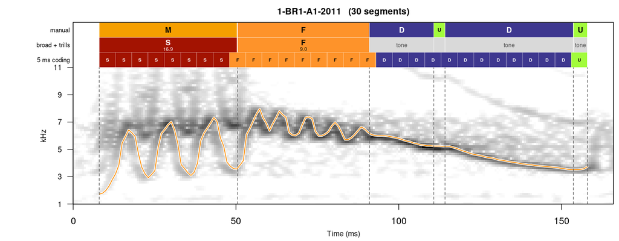

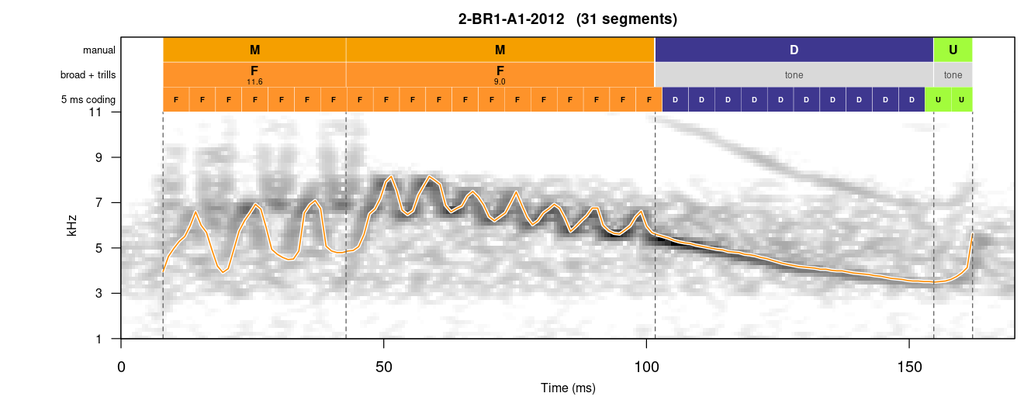

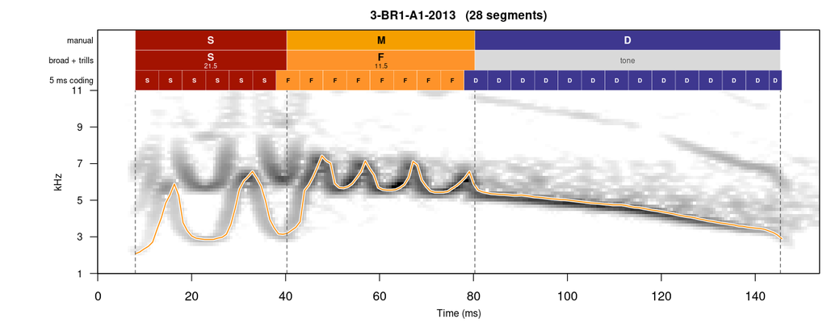

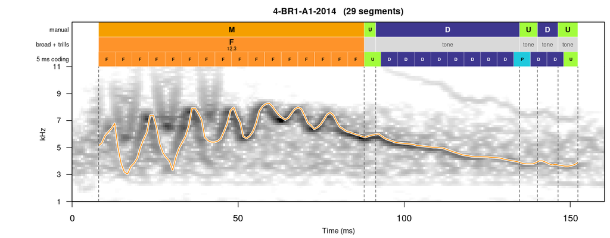

### 8.1.2 BR1-A2

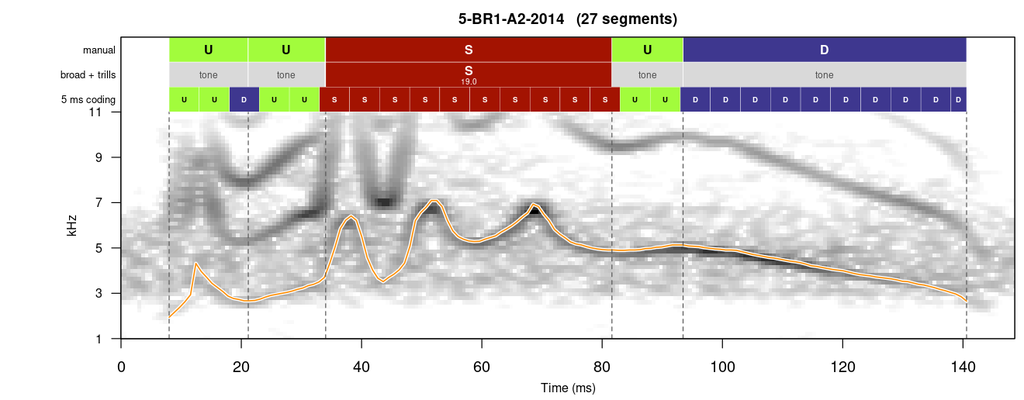

### 8.1.3 BR1-C1

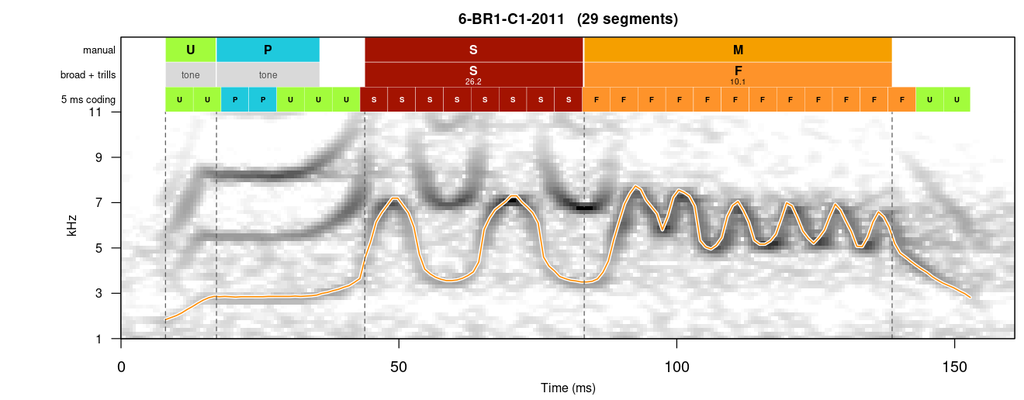

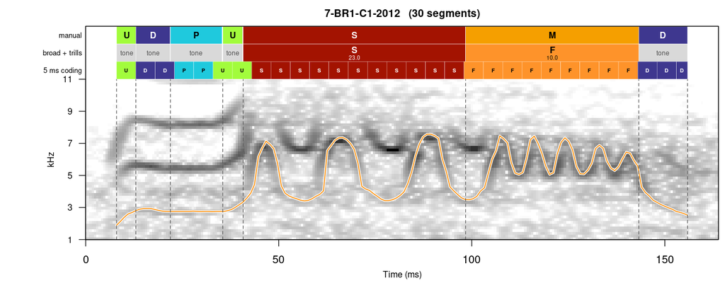

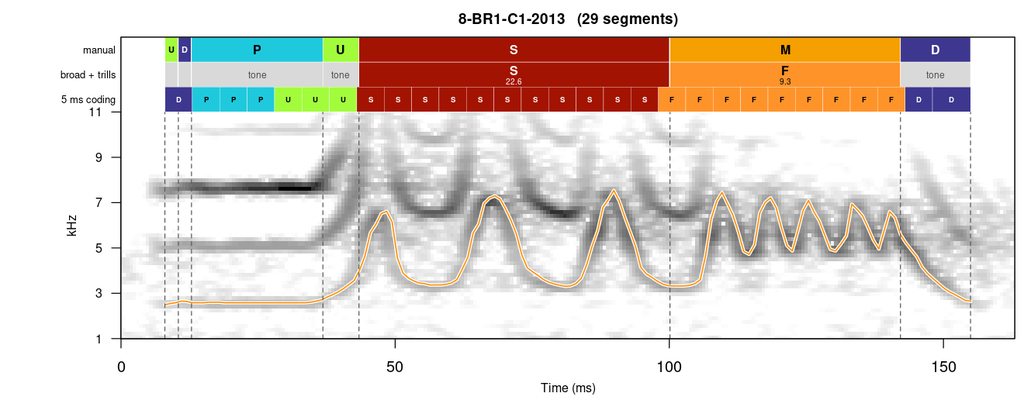

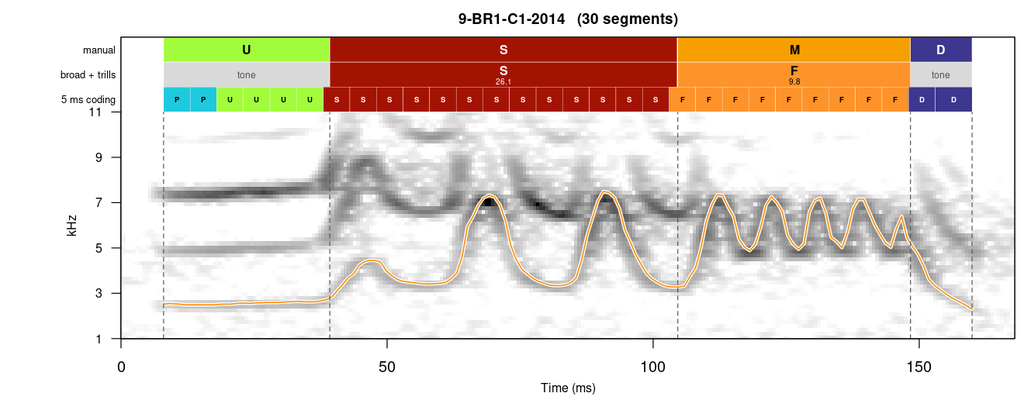

### 8.1.4 BR1-C2

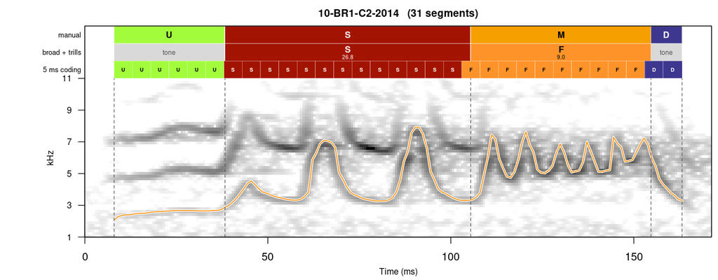

### 8.1.5 BR1-D1

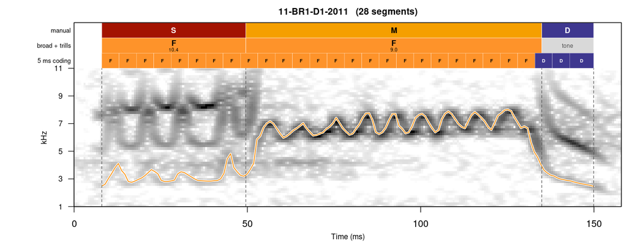

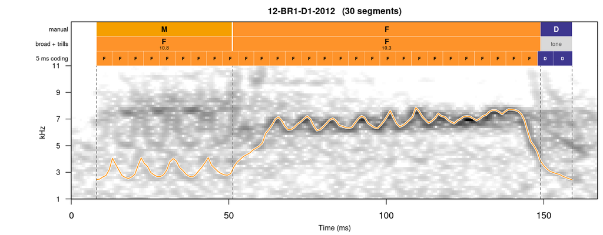

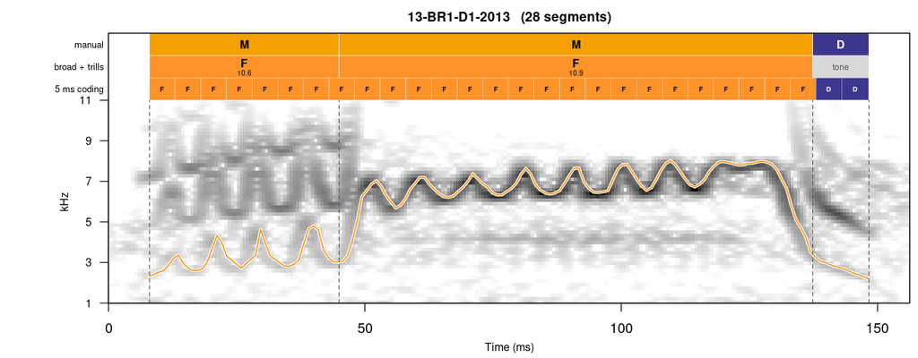

### 8.1.6 BR1-D2

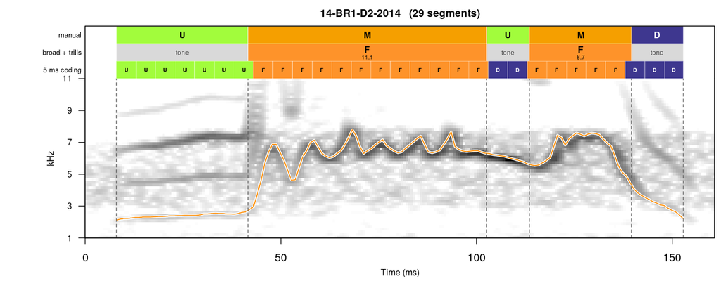

### 8.1.7 BR1-D3

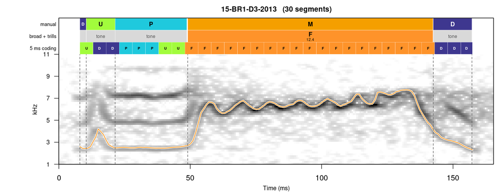

### 8.1.8 BR1-D4

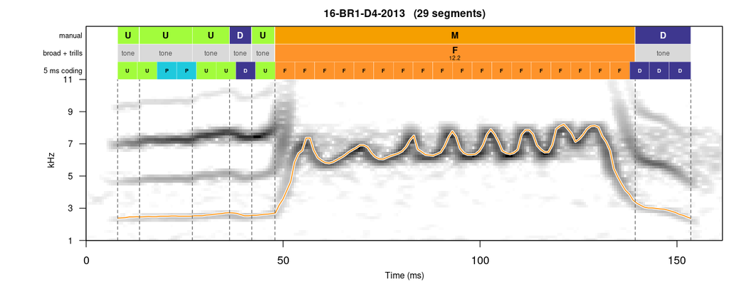

### 8.1.9 BR1-E1

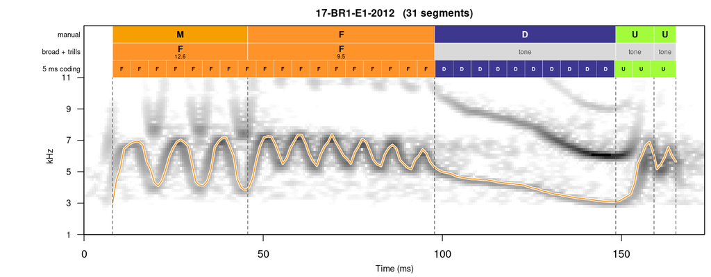

### 8.1.10 BR1-E2

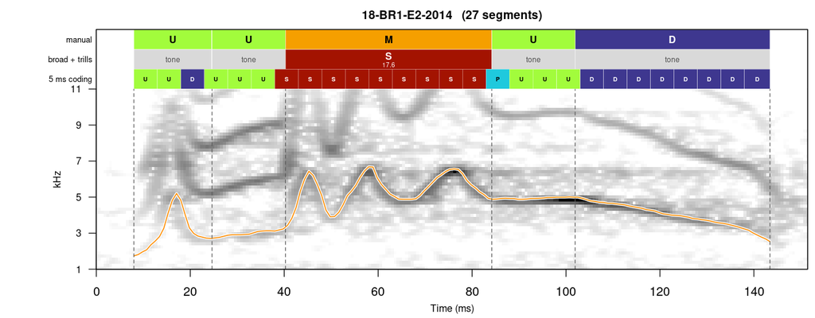

### 8.1.11 BR1-E3

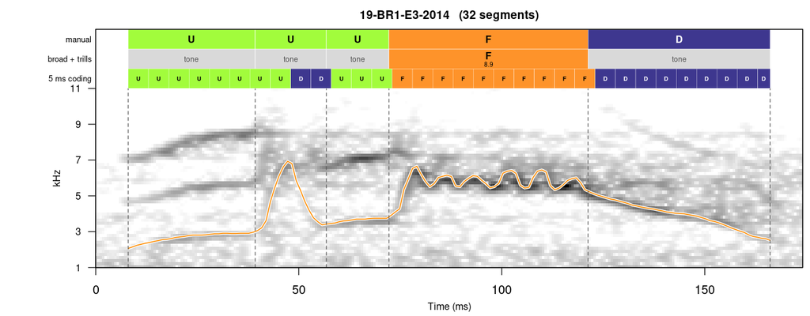

### 8.1.12 BR1-F1

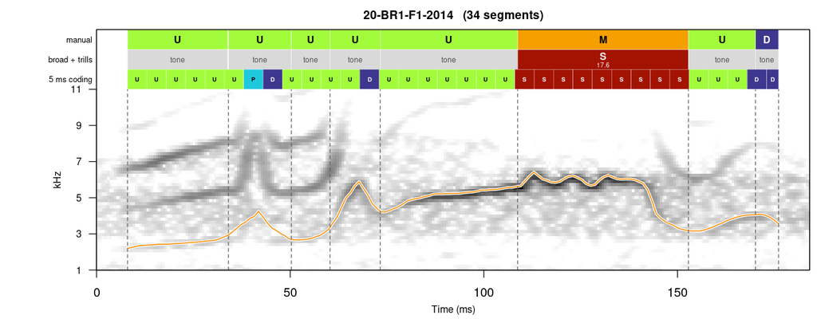

## 8.2 CCE

### 8.2.1 CCE-A1

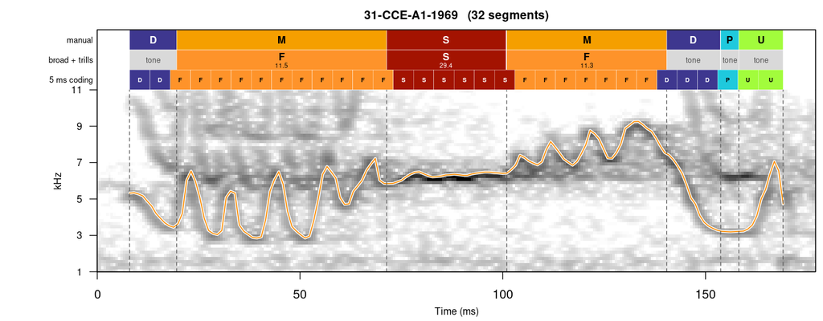

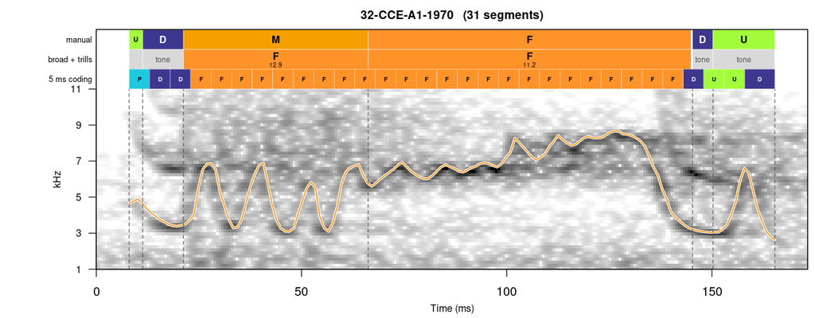

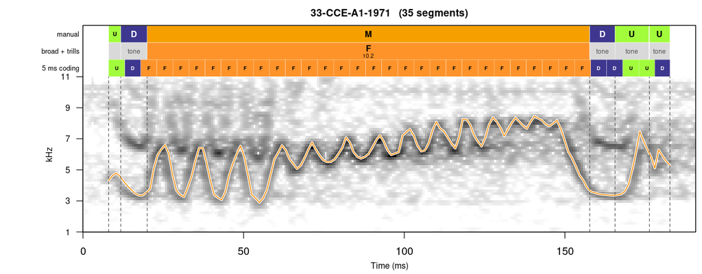

### 8.2.2 CCE-C1

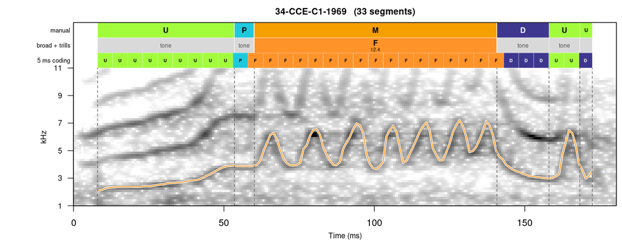

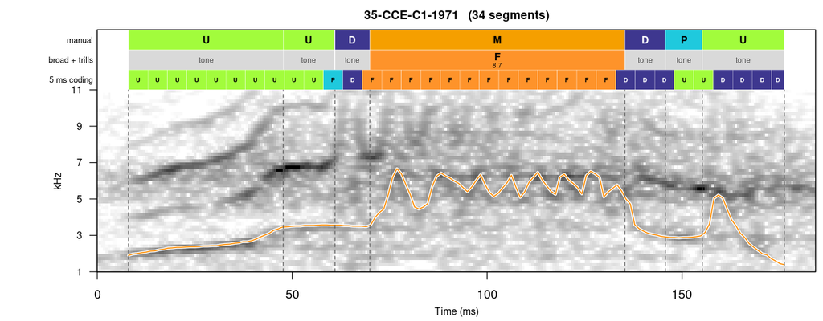

### 8.2.3 CCE-C2

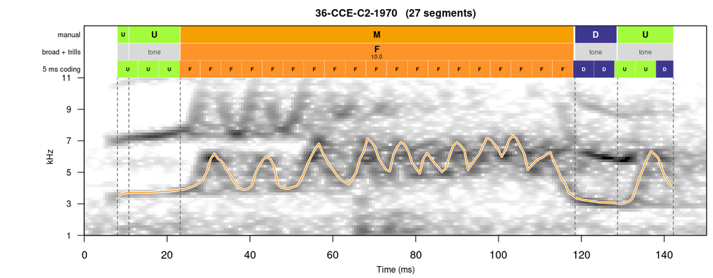

### 8.2.4 CCE-C3

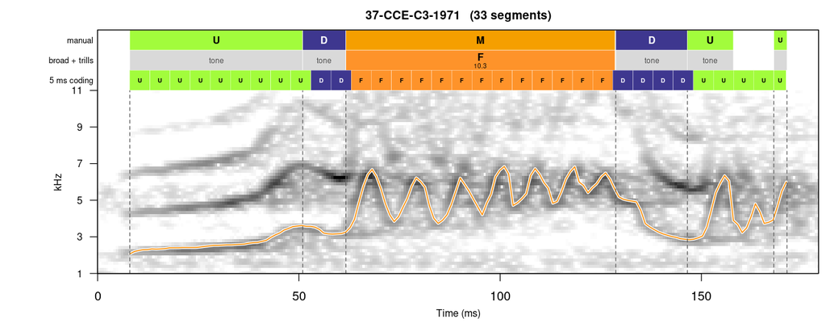